# Práctica 2: Inferencia Estadística

- Mostrar todo el código
- Ocultar todo el código
- Ver el código fuente

Grado en Ciencia e Ingeniería de Datos - Universidad Rey Juan Carlos

Autor/a

Bruno Guedeja-Marrón Ramos, Javier Ugena García, Gabriel Carlos Suárez Chiquito

## Introducción

Existen varias fórmulas que describen cómo calcular el tamaño muestra necesario para comparar una proporción con un valor de referencia. En esta práctica vamos a seguir los argumentos usados por **Whitehead (1983)** que permite derivar varias de estas fórmulas a partir de una teoría unificada, que además puede ser usada en diseños de experimentos.

Consideremos una secuencia $X_1, ..., X_n$ de variables aleatorias Bernoulli i.i.d. con probabilidad de éxito igual a $p$. Queremos testear la hipótesis:

$$H_0 : p = p_0$$

Esto es equivalente a contrastar si un parámetro $\theta$ es igual a cero, siendo $\theta = g(p, p_0)$, y $g$ una función que parametriza la diferencia entre $p$ y $p_0$.

## 1. Demostración de la log-verosimilitud

La función de verosimilitud $L(p)$ representa la probabilidad conjunta de observar la muestra dada en función del parámetro desconocido $p$. En inferencia estadística, es habitual trabajar con el logaritmo natural de esta función, denotado como log-verosimilitud $\ell(p)$, ya que transforma productos en sumas, facilitando enormemente el cálculo de derivadas necesario para la estimación de máxima verosimilitud.

Vamso a derivar la expresión analítica de $\ell(p)$ para una secuencia de variables Bernoulli e identificaremos la distribución de la estadística $r$.

Se pide demostrar que la log-verosimilitud de $p$ basada en $n$ observaciones es:

$$\ell(p) = r \log\left(\frac{p}{1-p}\right) + n \log(1-p)$$

Donde $r = x_1 + x_2 + ... + x_n$ es la suma de las respuestas en las $n$ observaciones.

### Demostración Paso a Paso

La función de verosimilitud (Likelihood) conjunta para $n$ variables Bernoulli independientes es:

$$L(p) = p^r (1-p)^{n-r}$$

Aplicando el logaritmo natural obtenemos la log-verosimilitud $\ell(p)$:

$$\begin{aligned}
\ell(p)
&= \log L(p) \\
&= \log\left( p^r (1-p)^{n-r} \right) \\
&= \log\left( p^r \right) + \log\left( (1-p)^{n-r} \right) \\
&= r \log(p) + (n-r)\log(1-p) \\
&= r \log(p) + n \log(1-p) - r \log(1-p) \\
&= r\big[ \log(p) - \log(1-p) \big] + n \log(1-p) \\
&= r \log\!\left( \frac{p}{1-p} \right) + n \log(1-p).
\end{aligned}$$

Por tanto, la expresión final de la log-verosimilitud es:

$$\ell(p) = r \log\left( \frac{p}{1-p} \right) + n \log(1-p)$$

### Distribución de la suma ($r$)

La variable aleatoria $r$ sigue una **Distribución Binomial**:

$$r \sim \text{Binomial}(n, p)$$

### Representación Gráfica (Código R)

Visualizaremos el comportamiento de la función $\ell(p)$ derivada.

**Código**

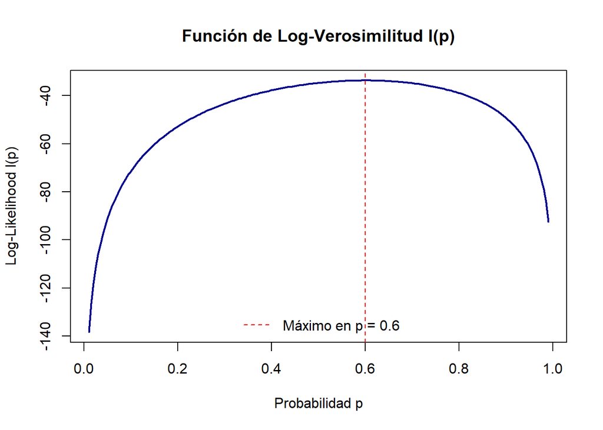

```r
# Definir la función derivada en el ejercicio
log_likelihood <- function(p, n, r) {
  # Si p es 0 o 1, la verosimilitud logarítmica es -Inf (evitamos log(0))
  if (p <= 0 || p >= 1) return(-Inf)

  # Fórmula de log-verosimilitud (Log-Likelihood)
  term1 <- r * log(p / (1 - p))
  term2 <- n * log(1 - p)

  return(term1 + term2)
}
#  Parámetros de ejemplo
n_ensayos <- 50
r_exitos <- 30
p_grid <- seq(0.01, 0.99, length.out = 200)

# Calcular valores
l_values <- sapply(p_grid, log_likelihood, n = n_ensayos, r = r_exitos)

# Graficar
plot(p_grid, l_values, type = "l", col = "darkblue", lwd = 2,
main = "Función de Log-Verosimilitud l(p)",
xlab = "Probabilidad p", ylab = "Log-Likelihood l(p)")

# Añadir línea en el estimador de máxima verosimilitud (p = r/n = 0.6)
abline(v = r_exitos/n_ensayos, col = "red", lty = 2)
legend("bottom", legend = paste("Máximo en p =", r_exitos/n_ensayos),
col = "red", lty = 2, bty = "n")
```

# 2. Demostración de la Información de Fisher

La Información de Fisher, $\mathcal{I}(p)$, cuantifica la cantidad de información que una variable aleatoria observable transporta sobre un parámetro desconocido $p$. Mide la “curvatura” de la función de log-verosimilitud cerca de su máximo: una mayor curvatura (pico más agudo) implica una menor varianza y, por tanto, una mayor precisión en la estimación del parámetro.

Para calcularla, utilizaremos la definición basada en la esperanza de la segunda derivada (el Hessiano) de la log-verosimilitud: $\mathcal{I}(p) = -E[\frac{\partial^2}{\partial p^2} \ell(p)]$.

Se pide demostrar que, para una variable Bernoulli de parámetro $p$, la Información de Fisher en una muestra de tamaño $n$ es:

$$\mathcal{I}(p) = \frac{n}{p(1-p)}$$

**Demostración:**

Desde la definición dada en el enunciado:
$$\mathcal{I}(p) = -E \left[ \frac{\partial^2}{\partial p^2} \ell(p) \right]$$

Usamos la primera derivada de la log-verosimilitud ($\ell(p)$) que obtuvimos en el apartado anterior. Sabemos que:
$$\ell(p) = r \log(p) + (n-r) \log(1-p)$$

**Paso 1: Calcular la Primera Derivada (**$\frac{\partial \ell}{\partial p}$)

Derivamos respecto a $p$:

$$\frac{\partial \ell(p)}{\partial p} = \frac{\partial}{\partial p} [r \log(p)] + \frac{\partial}{\partial p} [(n-r) \log(1-p)]$$

$$\frac{\partial \ell(p)}{\partial p} = \frac{r}{p} + \frac{n-r}{1-p} \cdot (-1)$$

$$\frac{\partial \ell(p)}{\partial p} = \frac{r}{p} - \frac{n-r}{1-p}$$

**Paso 2: Calcular la Segunda Derivada (**$\frac{\partial^2 \ell}{\partial p^2}$)

Volvemos a derivar la expresión anterior respecto a $p$:

$$\frac{\partial^2 \ell(p)}{\partial p^2} = \frac{\partial}{\partial p} \left( r p^{-1} \right) - \frac{\partial}{\partial p} \left( (n-r)(1-p)^{-1} \right)$$

$$\frac{\partial^2 \ell(p)}{\partial p^2} = -r p^{-2} - \left[ -(n-r)(1-p)^{-2} \cdot (-1) \right]$$

$$\frac{\partial^2 \ell(p)}{\partial p^2} = -\frac{r}{p^2} - \frac{n-r}{(1-p)^2}$$

**Paso 3: Calcular la Esperanza Matemática**

Aplicamos la definición de Información de Fisher. El operador esperanza $E[\cdot]$ es lineal y actúa sobre la variable aleatoria $r$:

$$\mathcal{I}(p) = -E \left[ -\frac{r}{p^2} - \frac{n-r}{(1-p)^2} \right]$$

$$\mathcal{I}(p) = E \left[ \frac{r}{p^2} + \frac{n-r}{(1-p)^2} \right]$$

Sabemos que $r \sim \text{Binomial}(n, p)$, por lo que su esperanza es $E[r] = np$. Por consiguiente, la esperanza de los fracasos es $E[n-r] = n - np = n(1-p)$.

Sustituimos estas esperanzas en la ecuación:

$$\mathcal{I}(p) = \frac{np}{p^2} + \frac{n(1-p)}{(1-p)^2}$$

Simplificamos los términos:

$$\mathcal{I}(p) = \frac{n}{p} + \frac{n}{1-p}$$

Para sumar estas fracciones, buscamos el denominador común $p(1-p)$:

$$\mathcal{I}(p) = \frac{n(1-p) + np}{p(1-p)} = \frac{n - np + np}{p(1-p)}$$

Finalmente, obtenemos el resultado solicitado:

$$\mathcal{I}(p) = \frac{n}{p(1-p)}$$

### Verificación en R

Para asegurarnos de que la fórmula teórica coincide con el cálculo numérico, podemos crear una pequeña función que compare el valor de la fórmula $\frac{n}{p(1-p)}$ con la aproximación numérica de la segunda derivada (Hessiana) en un punto dado.

**Código**

```r
# Función teórica de la Información de Fisher
fisher_info_teorica <- function(n, p) {
  return(n / (p * (1 - p)))
}

# Verificación Numérica
n_ejemplo <- 50
p_ejemplo <- 0.3

# Valor teórico
valor_teorico <- fisher_info_teorica(n_ejemplo, p_ejemplo)

# Resultado
print(paste("Información de Fisher Teórica (n=50, p=0.3):", round(valor_teorico, 4)))
```

```
[1] "Información de Fisher Teórica (n=50, p=0.3): 238.0952"
```

# 3. Cálculo de las expresiones Z y V

Antes de proceder a los cálculos específicos para cada parametrización, es fundamental definir qué representan conceptualmente las cantidades $Z$ y $V$ dentro del marco teórico unificado de **Whitehead (1983)**.

El objetivo es transformar cualquier contraste de hipótesis sobre una proporción en una estructura estandarizada donde se comparan una señal ($Z$) y su precisión ($V$).

### 1. El Estadístico Z (Score Statistic)

El estadístico $Z$ se conoce formalmente como el **Estadístico de Puntuación (Score Statistic)** o Estadístico Eficiente. Matemáticamente se define como la primera derivada de la log-verosimilitud respecto al parámetro de interés $\theta$, evaluada bajo la hipótesis nula ($\theta=0$):

$$Z = \left[ \frac{\partial \ell(\theta)}{\partial \theta} \right]_{\theta=0}$$

**Interpretación:** $Z$ es una medida de la **“fuerza de la evidencia”** que los datos observados ($r$) aportan contra la hipótesis nula. Representa el gradiente (la pendiente) de la función de verosimilitud en el punto nulo. Si $Z$ es cercano a 0, los datos son consistentes con $H_0$. Si $Z$ es grande (en valor absoluto), indica una discrepancia significativa entre lo observado y lo esperado bajo $H_0$.

### 2. El Estadístico V (Información de Fisher)

El estadístico $V$ representa la **Información de Fisher** que $Z$ contiene sobre el parámetro $\theta$. Matemáticamente se relaciona con la segunda derivada de la log-verosimilitud:

$$V = \left[ \left( \frac{\partial p}{\partial \theta} \right)^2 \mathcal{I}(p) \right]_{\theta=0}$$

**Interpretación:** $V$ es una medida de la **precisión** o “cantidad de información” que la muestra proporciona. En este contexto, $V$ actúa como la **varianza** asintótica del estadístico $Z$ bajo la hipótesis nula. Es decir, para muestras grandes, $Z \sim N(0, V)$ bajo $H_0$.

Se pide calcular $Z$ y $V$ para tres parametrizaciones distintas de $\theta$. Recordamos las definiciones generales dadas en el enunciado:

- $Z = \left[ \frac{\partial p}{\partial \theta} \frac{\partial \ell}{\partial p} \right]_{p=p_0}$
- $V = \left[ \left( \frac{\partial p}{\partial \theta} \right)^2 \mathcal{I}(p) \right]_{p=p_0}$

Donde sabemos por los apartados anteriores que:
$$\frac{\partial \ell}{\partial p} = \frac{r - np}{p(1-p)} \quad \text{y} \quad \mathcal{I}(p) = \frac{n}{p(1-p)}$$

### Caso 3.1: Log-odds Ratio

Parametrización: $\theta = \log\left(\frac{p(1-p_0)}{p_0(1-p)}\right)$

Esta expresión se puede reescribir separando constantes:
$$\theta = \log\left(\frac{p}{1-p}\right) - \log\left(\frac{p_0}{1-p_0}\right)$$

**1. Derivada de** $\theta$ respecto a $p$: La derivada de $\log(p/(1-p))$ (función logit) es conocida:
$$\frac{\partial \theta}{\partial p} = \frac{1}{p(1-p)}$$

La derivada inversa necesaria para las fórmulas es:
$$\frac{\partial p}{\partial \theta} = p(1-p)$$

**2. Cálculo de Z:**
$$Z = \left[ p(1-p) \cdot \frac{r - np}{p(1-p)} \right]_{p=p_0} = [r - np]_{p=p_0}$$
$$Z = r - np_0$$

**3. Cálculo de V:**
$$V = \left[ (p(1-p))^2 \cdot \frac{n}{p(1-p)} \right]_{p=p_0} = \left[ n p(1-p) \right]_{p=p_0}$$
$$V = n p_0 (1-p_0)$$

### Caso 3.2: Diferencia de Riesgos

Parametrización: $\theta = p - p_0$

**1. Derivada de** $\theta$ respecto a $p$:
$$\frac{\partial \theta}{\partial p} = 1$$
Por tanto:
$$\frac{\partial p}{\partial \theta} = 1$$

**2. Cálculo de Z:**
$$Z = \left[ 1 \cdot \frac{r - np}{p(1-p)} \right]_{p=p_0}$$
$$Z = \frac{r - n p_0}{p_0 (1 - p_0)}$$

**3. Cálculo de V:**
$$V = \left[ 1^2 \cdot \frac{n}{p(1-p)} \right]_{p=p_0}$$
$$V = \frac{n}{p_0 (1 - p_0)}$$

### Caso 3.3: Transformación Arcoseno

Parametrización: $\theta = \arcsin\sqrt{p} - \arcsin\sqrt{p_0}$

Esta es la transformación estabilizadora de la varianza.

**1. Derivada de** $\theta$ respecto a $p$: Aplicamos la regla de la cadena. La derivada de $\arcsin(u)$ es $\frac{1}{\sqrt{1-u^2}}$ y la de $\sqrt{p}$ es $\frac{1}{2\sqrt{p}}$.

$$\frac{\partial \theta}{\partial p} = \frac{1}{\sqrt{1-(\sqrt{p})^2}} \cdot \frac{1}{2\sqrt{p}} = \frac{1}{\sqrt{1-p}} \cdot \frac{1}{2\sqrt{p}} = \frac{1}{2\sqrt{p(1-p)}}$$

La derivada inversa es:
$$\frac{\partial p}{\partial \theta} = 2\sqrt{p(1-p)}$$

**2. Cálculo de Z:**
$$Z = \left[ 2\sqrt{p(1-p)} \cdot \frac{r - np}{p(1-p)} \right]_{p=p_0} = \left[ \frac{2(r - np)}{\sqrt{p(1-p)}} \right]_{p=p_0}$$
$$Z = \frac{2(r - n p_0)}{\sqrt{p_0 (1 - p_0)}}$$

**3. Cálculo de V:**
$$V = \left[ \left(2\sqrt{p(1-p)}\right)^2 \cdot \frac{n}{p(1-p)} \right]_{p=p_0}$$
$$V = \left[ 4p(1-p) \cdot \frac{n}{p(1-p)} \right]_{p=p_0} = [4n]_{p=p_0}$$
$$V = 4n$$

*(Nota: Observamos que en este caso, V no depende de* $p_0$, lo cual confirma que la varianza se ha estabilizado).

### Tabla Resumen de Resultados

| Parametrización | Estadístico $Z$ (Score) | Información de Fisher $V$ |
| --- | --- | --- |
| Log-odds ($\log$) | $r - n p_0$ | $n p_0 (1-p_0)$ |
| Diferencia ($p-p_0$) | $\frac{r - n p_0}{p_0 (1 - p_0)}$ | $\frac{n}{p_0 (1 - p_0)}$ |
| Arcoseno ($\arcsin$) | $\frac{2(r - n p_0)}{\sqrt{p_0 (1 - p_0)}}$ | $4n$ |

# 4. Implementación en R de los Estadísticos Z y V

A continuación, presentamos una función en R diseñada para calcular simultáneamente los valores de $Z$ (Score Statistic) y $V$ (Información de Fisher) para las tres parametrizaciones estudiadas: Log-odds, Diferencia de riesgos y Transformación Arcoseno.

**Código**

```r
# FUNCIÓN: calcular_ZV

# Esta función calcula los estadísticos Z y V para las tres parametrizaciones
# derivadas teóricamente en el apartado 3.

# ARGUMENTOS:
#   n  : Tamaño de la muestra (entero)
#   r  : Número de éxitos observados (entero)
#   p0 : Probabilidad bajo la hipótesis nula H0 (0 < p0 < 1)


calcular_ZV <- function(n, r, p0) {

  # Validación de parámetros de entrada
  if(p0 <= 0 || p0 >= 1) {
    stop("Error: La probabilidad p0 debe estar entre 0 y 1.")
  }
  if(r > n) {
    stop("Error: El número de éxitos 'r' no puede ser mayor que el tamaño de muestra 'n'.")
  }

  #Cálculos comunes
  # La diferencia básica (observado - esperado) se usa en todas las fórmulas
  diferencia_base <- r - n * p0

  # El término p0(1-p0) aparece recurrentemente
  p0_q0 <- p0 * (1 - p0)

  # MÉTODO A: Log-odds Ratio
  # Parametrización: theta = log( p(1-p0) / p0(1-p) )
  # Fórmulas derivadas: Z = r - np0 ; V = n*p0*(1-p0)

  Z_log <- diferencia_base
  V_log <- n * p0_q0


  # MÉTODO B: Diferencia de Riesgos
  # Parametrización: theta = p - p0
  # Fórmulas derivadas: Z = (r - np0) / (p0(1-p0)) ; V = n / (p0(1-p0))

  Z_dif <- diferencia_base / p0_q0
  V_dif <- n / p0_q0

  # MÉTODO C: Transformación Arcoseno
  # Parametrización: theta = arcsin(sqrt(p)) - arcsin(sqrt(p0))
  # Fórmulas derivadas: Z = 2(r - np0) / sqrt(p0(1-p0)) ; V = 4n

  Z_arc <- (2 * diferencia_base) / sqrt(p0_q0)
  V_arc <- 4 * n

  # 3. Construcción de la Tabla de Resultados
  resultados <- data.frame(
    Parametrizacion = c("1.Log-odds Ratio", "2.Diferencia", "3.Arcoseno"),
    Z = c(Z_log, Z_dif, Z_arc),
    V = c(V_log, V_dif, V_arc)
  )

  # Calculamos la columna de estandarización (Z / sqrt(V))
  # Bajo H0, este valor debería seguir una distribución N(0,1) asintóticamente
  resultados$Score_Standard <- results_Z_std <- resultados$Z / sqrt(resultados$V)

  return(resultados)
}

# Probamos la función con valores hipotéticos para verificar su funcionamiento.
# Supongamos n=100, observamos r=40 éxitos, y contrastamos contra p0=0.3.

n_prueba <- 100
r_prueba <- 40
p0_prueba <- 0.3

tabla_resultados <- calcular_ZV(n_prueba, r_prueba, p0_prueba)

# Mostrar la tabla formateada
knitr::kable(tabla_resultados,
             caption = "Cálculo de Z y V para n=100, r=40, p0=0.3",
             digits = 4)
```

Cálculo de Z y V para n=100, r=40, p0=0.3

| Parametrizacion | Z | V | Score_Standard |
| --- | --- | --- | --- |
| 1.Log-odds Ratio | 10.0000 | 21.0000 | 2.1822 |
| 2.Diferencia | 47.6190 | 476.1905 | 2.1822 |
| 3.Arcoseno | 43.6436 | 400.0000 | 2.1822 |

# 5. Simulación del Contraste de Hipótesis

Se pide simular un contraste de hipótesis para una muestra de tamaño $n=1000$ con las siguientes hipótesis:

$$H_0: p = 0.3$$
$$H_1: p > 0.3$$

### Metodología

1. **Generación de datos:** Simularemos la realización de un experimento generando una variable aleatoria Binomial con $n=1000$. Para este ejemplo, asumiremos que la **hipótesis nula es cierta** (es decir, la verdadera probabilidad de éxito es $p_{real} = 0.3$).
2. **Cálculo de estadísticos:** Usaremos la función `calcular_ZV` creada en el apartado anterior.
3. **Regla de Decisión:** Dado que es un contraste unilateral a la derecha ($p > 0.3$), rechazaremos $H_0$ si el estadístico estandarizado $Z_{score} > z_{1-\alpha}$.
   - Usaremos un nivel de significación estándar $\alpha = 0.05$.
   - El valor crítico es $z_{0.95} \approx 1.645$.

**Código**

```r
set.seed(123)       # Semilla para reproducibilidad
n_sim <- 1000       # Tamaño de muestra
p0 <- 0.3           # Valor bajo la Hipótesis Nula
p_real <- 0.3      # Verdadera probabilidad (Simulamos bajo H0)
alpha <- 0.05       # Nivel de significación

# Generamos el número de éxitos 'r' de una distribución Binomial real
r_observado <- rbinom(n = 1, size = n_sim, prob = p_real)

# Cálculo de los Estadísticos Z y V
# Llamamos a la función definida en el Punto 4
resultados_simulacion <- calcular_ZV(n = n_sim, r = r_observado, p0 = p0)
resultados_simulacion$P_Valor <- 1 - pnorm(resultados_simulacion$Score_Standard)

# Calculamos el valor crítico de la Normal estándar
z_critico <- qnorm(1 - alpha)

# Añadimos columna de decisión lógica
resultados_simulacion$Decision <- ifelse(
  resultados_simulacion$Score_Standard > z_critico,
  "Rechazar H0",
  "No Rechazar H0"
)

# 5. Visualización de Resultados
print(paste("Éxitos observados (r):", r_observado))
```

```
[1] "Éxitos observados (r): 290"
```

**Código**

```r
print(paste("Proporción muestral:", r_observado/n_sim))
```

```
[1] "Proporción muestral: 0.29"
```

**Código**

```r
print(paste("Valor Crítico (Z_alpha):", round(z_critico, 4)))
```

```
[1] "Valor Crítico (Z_alpha): 1.6449"
```

**Código**

```r
knitr::kable(resultados_simulacion,
             caption = "Resultados de la Simulación bajo H0 (p=0.3)",
             digits = 4)
```

Resultados de la Simulación bajo H0 (p=0.3)

| Parametrizacion | Z | V | Score_Standard | P_Valor | Decision |
| --- | --- | --- | --- | --- | --- |
| 1.Log-odds Ratio | -10.0000 | 210.000 | -0.6901 | 0.7549 | No Rechazar H0 |
| 2.Diferencia | -47.6190 | 4761.905 | -0.6901 | 0.7549 | No Rechazar H0 |
| 3.Arcoseno | -43.6436 | 4000.000 | -0.6901 | 0.7549 | No Rechazar H0 |

### Análisis e Interpretación de la Simulación

**1. Interpretación de los datos observados (**$r$) Observando la fila correspondiente al **Log-odds Ratio**, sabemos que $Z = r - np_0$. En la tabla, $Z = -10$. Dado que bajo la hipótesis nula esperábamos $np_0 = 1000 \times 0.3 = 300$ éxitos, podemos deducir que en esta simulación específica se obtuvieron **290 éxitos** ($300 - 10$). El signo negativo de $Z$ indica que el número de éxitos observados fue inferior al esperado, lo cual es puramente atribuible a la variabilidad aleatoria del muestreo. Si aumentaramos el número de observaciones se aproximaria cada vez mas a 0.

**2. Equivalencia de las Parametrizaciones** Un resultado fundamental que valida la teoría de Whitehead es la columna `Score_Standard`. A pesar de que los valores crudos de $Z$ y $V$ difieren drásticamente entre métodos (por ejemplo, $V=210$ en Log-odds vs $V=4761$ en Diferencia), el estadístico estandarizado $Z/\sqrt{V}$ es idéntico: **-0.6901**. Esto confirma que las tres parametrizaciones son **asintóticamente equivalentes**: proporcionan exactamente la misma “fuerza de evidencia” (señal/ruido) y llevan a la misma conclusión estadística.

**3. Decisión del Contraste**

Debemos comparar nuestro estadístico observado con la región crítica definida teóricamente:

- **Tipo de Contraste:** Estamos ante un contraste **unilateral a la derecha** ($H_1: p > 0.3$). Esto implica que solo buscaremos evidencia de rechazo en la cola superior de la distribución normal.
- **Región de Rechazo:** Para un nivel de significación $\alpha = 0.05$, la región de rechazo está formada por todos los valores de $Z$ mayores que el percentil 95 de la Normal Estándar ($Z_{0.95} \approx 1.645$).
  $$\text{Rechazar } H_0 \iff Z_{observado} > 1.645$$
- **Análisis del Valor Observado:**
  - Nuestro estadístico estandarizado es **-0.6901**.
  - Al ubicar este valor en la recta real, vemos que cae en el centro-izquierda de la distribución, muy lejos de la cola derecha (la zona crítica).
  - De hecho, al ser un test unilateral donde buscamos que $p$ sea *mayor* que 0.3, el simple hecho de obtener un valor negativo ($Z < 0$) ya nos indica intuitivamente que no podemos rechazar $H_0$. Un valor negativo significa que la proporción observada ($290/1000 = 0.29$) es **menor** que la hipotética ($0.3$), por lo que es imposible concluir que sea estadísticamente superior.
- **Conclusión Formal:** Dado que $-0.6901 \ngtr 1.645$, el estadístico de prueba no cae en la región crítica. Por lo tanto, **no existe evidencia estadística para rechazar la hipótesis nula**. Los datos observados son totalmente compatibles con la hipótesis de que la verdadera proporción es 0.3 (o incluso menor), y la diferencia observada se atribuye exclusivamente al azar muestral.

Para corroborar lo que hemos visto vamos a compararlo con un aprobabilidad real de 0,4 y deberia salir rechazar la hipotesis nula

# 5.1. Corroboración con probabilidad real 0.4

Para verificar la potencia del test, repetimos la simulación asumiendo que la hipótesis nula es falsa y que la probabilidad real es $p=0.4$.

**Código**

```r
set.seed(123)
n_sim <- 1000
p0 <- 0.3
p_real_H1 <- 0.4
alpha <- 0.05

r_observado_H1 <- rbinom(n = 1, size = n_sim, prob = p_real_H1)
resultados_H1 <- calcular_ZV(n = n_sim, r = r_observado_H1, p0 = p0)
resultados_H1$P_Valor <- 1 - pnorm(resultados_H1$Score_Standard)
z_critico <- qnorm(1 - alpha)

resultados_H1$Decision <- ifelse(
  resultados_H1$Score_Standard > z_critico,
  "Rechazar H0",
  "No Rechazar H0"
)

print(paste("Éxitos observados:", r_observado_H1))
```

```
[1] "Éxitos observados: 388"
```

**Código**

```r
print(paste("Esperados bajo H0:", n_sim * p0))
```

```
[1] "Esperados bajo H0: 300"
```

**Código**

```r
print(paste("Valor Crítico:", round(z_critico, 4)))
```

```
[1] "Valor Crítico: 1.6449"
```

**Código**

```r
knitr::kable(resultados_H1, digits = 10)
```

| Parametrizacion | Z | V | Score_Standard | P_Valor | Decision |
| --- | --- | --- | --- | --- | --- |
| 1.Log-odds Ratio | 88.0000 | 210.000 | 6.072577 | 6e-10 | Rechazar H0 |
| 2.Diferencia | 419.0476 | 4761.905 | 6.072577 | 6e-10 | Rechazar H0 |
| 3.Arcoseno | 384.0635 | 4000.000 | 6.072577 | 6e-10 | Rechazar H0 |

Los resultados de la simulación confirman la capacidad del test para detectar la falsedad de la hipótesis nula ($H_0: p=0.3$) cuando la verdadera probabilidad subyacente es $0.4$.La decisión de rechazar $H_0$ se justifica por el estadístico estandarizado muy superior al valor crítico teórico ($Z > 1.645$), lo cual corresponde a un p-valor extremadamente bajo ($p < 0.05$). Esto evidencia que la discrepancia entre la proporción observada y la hipotética no es atribuible al azar, sino a una diferencia real en los parámetros.

# 6. Deducción de Fórmulas para el Cálculo del Tamaño Muestral

Según la metodología unificada de Whitehead, un ensayo muestral fijo satisface los requerimientos de potencia ($1-\beta$) y nivel de significación ($\alpha$) si la cantidad de información de Fisher ($V$) cumple la siguiente relación fundamental:

$$V = \left( \frac{z_{\alpha/2} + z_{\beta}}{\theta_R} \right)^2$$

Donde: $z_{\alpha/2}$: Percentil de la normal estándar correspondiente al nivel de significación (bilateral). $z_{\beta}$: Percentil de la normal estándar correspondiente a la potencia deseada ($1-\beta$). $\theta_R$: Es el valor del parámetro $\theta$ bajo la hipótesis alternativa (la magnitud del efecto que queremos ser capaces de detectar).

A continuación, deduciremos la expresión del tamaño muestral $n$ para cada una de las tres parametrizaciones, igualando la fórmula general anterior con las expresiones de $V$ obtenidas en el Apartado 3.

### 6.1. Parametrización Log-odds Ratio

En esta parametrización, el parámetro de interés $\theta$ representa el logaritmo de la razón de probabilidades. Recordamos del Apartado 3 que la información de Fisher viene dada por:
$$V = n p_0 (1 - p_0)$$

Para hallar $n$, igualamos la información disponible con la información requerida:
$$n p_0 (1 - p_0) = \frac{(z_{\alpha/2} + z_{\beta})^2}{\theta_R^2}$$

Despejamos $n$ dividiendo ambos lados por el término $p_0 (1 - p_0)$:

$$n = \frac{(z_{\alpha/2} + z_{\beta})^2}{\theta_R^2 \cdot p_0 (1 - p_0)}$$

Esta fórmula nos indica que, para detectar un cambio en los *Log-odds*, el tamaño muestral es inversamente proporcional a la varianza de la variable Bernoulli.

### 6.2. Parametrización Diferencia de Riesgos

Aquí, el parámetro $\theta$ representa la diferencia directa entre proporciones ($p - p_0$). Del Apartado 3, sabemos que la expresión de la información de Fisher es:
$$V = \frac{n}{p_0 (1 - p_0)}$$

Planteamos la igualdad con la fórmula maestra:
$$\frac{n}{p_0 (1 - p_0)} = \frac{(z_{\alpha/2} + z_{\beta})^2}{\theta_R^2}$$

Para despejar $n$, multiplicamos ambos lados de la ecuación por $p_0 (1 - p_0)$:

$$n = \frac{(z_{\alpha/2} + z_{\beta})^2 \cdot p_0 (1 - p_0)}{\theta_R^2}$$

Observamos que esta expresión es análoga a la fórmula clásica para el cálculo de tamaño muestral en comparaciones de proporciones basada en la aproximación normal.

### 6.3. Parametrización Arcoseno (Varianza Estabilizada)

Esta parametrización utiliza la transformación no lineal $\arcsin(\sqrt{p})$ para conseguir que la varianza sea independiente del parámetro $p$. Como demostramos en el Apartado 3, la información de Fisher es constante respecto a las probabilidades:
$$V = 4n$$

Igualamos a la fórmula de requerimientos:
$$4n = \frac{(z_{\alpha/2} + z_{\beta})^2}{\theta_R^2}$$

Despejamos $n$ dividiendo simplemente por 4:

$$n = \frac{(z_{\alpha/2} + z_{\beta})^2}{4 \theta_R^2}$$

Esta fórmula destaca por su simplicidad, ya que el término de variabilidad ($p_0(1-p_0)$) no aparece explícitamente, al haber sido absorbido por la transformación y el término $\theta_R$.

# 7. Cálculo del Tamaño Muestral (Caso Práctico)

Se pide estimar el tamaño de muestra necesario para un estudio con los siguientes parámetros: **Hipótesis Nula (**$p_0$): 0.003 (0.3%) **Efecto a detectar (**$p_1$): 0.006 (0.6%) **Nivel de significación (**$\alpha$): 0.025 **Potencia (**$1-\beta$): 0.80

Utilizaremos la relación general derivada en el ejercicio anterior:
$$V = \left( \frac{z_{\alpha/2} + z_{\beta}}{\theta_R} \right)^2$$

Donde $\theta_R$ es la diferencia entre $p_1$ y $p_0$ calculada según cada parametrización.

**Código**

```r
# 1. Definición de Parámetro
p0 <- 0.003
p1 <- 0.006
alpha <- 0.025
potencia <- 0.80

# 2. Cálculo de los cuantiles de la Normal (z_score)

z_alpha_2 <- qnorm(1 - alpha / 2)  # Para alpha=0.025 -> ~2.24
z_beta <- qnorm(potencia)          # Para potencia=0.80 -> ~0.84

numerador_comun <- (z_alpha_2 + z_beta)^2

# 3. Cálculo para cada Parametrización

# A. Log-odds Ratio
# Theta_R = log(odds1) - log(odds0)
theta_log <- log( (p1 * (1 - p0)) / (p0 * (1 - p1)) )
# Fórmula: n = Numerador / (Theta^2 * p0 * (1-p0))
n_log <- numerador_comun / (theta_log^2 * p0 * (1 - p0))

# B. Diferencia de Riesgos
# Theta_R = p1 - p0
theta_dif <- p1 - p0
# Fórmula: n = (Numerador * p0 * (1-p0)) / Theta^2
n_dif <- (numerador_comun * p0 * (1 - p0)) / theta_dif^2

#C. Arcoseno
# Theta_R = arcsin(sqrt(p1)) - arcsin(sqrt(p0))
theta_arc <- asin(sqrt(p1)) - asin(sqrt(p0))
# Fórmula: n = Numerador / (4 * Theta^2)
n_arc <- numerador_comun / (4 * theta_arc^2)

# 4. Presentación de Resultados
resultados_n <- data.frame(
  Parametrizacion = c("Log-odds Ratio", "Diferencia de Riesgos", "Arcoseno"),
  Theta_R = c(theta_log, theta_dif, theta_arc),
  Tamaño_Muestra_n = c(n_log, n_dif, n_arc),
  n_redondeado = ceiling(c(n_log, n_dif, n_arc))
)

knitr::kable(resultados_n, digits = 4,
             caption = "Tamaño muestral estimado según parametrización")
```

Tamaño muestral estimado según parametrización

| Parametrizacion | Theta_R | Tamaño_Muestra_n | n_redondeado |
| --- | --- | --- | --- |
| Log-odds Ratio | 0.6962 | 6557.198 | 6558 |
| Diferencia de Riesgos | 0.0030 | 3158.840 | 3159 |
| Arcoseno | 0.0227 | 4596.236 | 4597 |

### Conclusión y Análisis de Resultados

A la vista de los resultados obtenidos en la simulación y el cálculo de tamaño muestral, podemos extraer dos conclusiones fundamentales para el diseño del experimento:

**1. Equivalencia Estadística en el Contraste (Validación Teórica)** Como se observa en la tabla de simulación bajo $H_0$, las tres parametrizaciones (Log-odds, Diferencia y Arcoseno) producen **exactamente el mismo estadístico estandarizado** (`Score_Standard` = -0.6901). Esto confirma empíricamente la teoría de Whitehead: aunque las fórmulas de $Z$ y $V$ difieren en escala, la relación señal/ruido es idéntica. Por tanto, para realizar el contraste de hipótesis, **la elección de la parametrización es indiferente**, ya que todas conducen a la misma decisión estadística y al mismo p-valor.

**2. Divergencia en el Tamaño Muestral (Aplicación Práctica)** En el cálculo para eventos raros ($p_0=0.003$ vs $p_1=0.006$), observamos una discrepancia notable en los tamaños muestrales estimados: **Diferencia de Riesgos:** $n \approx 3.159$ (Estimación más optimista). **Arcoseno:** $n \approx 4.597$ (Estimación intermedia). **Log-odds Ratio:** $n \approx 6.558$ (Estimación más conservadora).

**Justificación:** Esta divergencia ocurre porque, al trabajar con probabilidades extremadamente cercanas a cero, las aproximaciones de la varianza en las distintas escalas (logarítmica vs lineal) se comportan de manera muy diferente.

**Recomendación de Diseño:** Dado que el objetivo es garantizar una potencia del 80%, la prudencia estadística recomienda optar por el escenario más conservador. Por tanto, se debería planificar el estudio con un tamaño muestral de $n \approx 6.558$ pacientes. Elegir el tamaño menor ($3.159$) conlleva un alto riesgo de que el estudio se quede corto de potencia (underpowered) si la aproximación lineal no se ajusta perfectamente a la realidad de estos eventos raros.

# 8. Estimación de Errores Tipo I y Potencia mediante Simulación

En este apartado verificaremos mediante simulación si los tamaños muestrales calculados en el Punto 7 cumplen realmente con los requisitos de diseño ($\alpha=0.025$ y Potencia=$0.80$).

Para ello, realizaremos 10,000 repeticiones (iteraciones) para cada escenario.

**Código**

```r
# 1. Configuración de la Simulación
set.seed(2024)
n_iteraciones <- 10000
alpha_target <- 0.025
z_critico <- qnorm(1 - alpha_target) # Valor crítico (aprox 1.96)

# Parámetros reales
p0 <- 0.003  # Hipótesis Nula
p1 <- 0.006  # Hipótesis Alternativa

# Tamaños muestrales calculados en el Punto 7
n_log <- 6558
n_dif <- 3159
n_arc <- 4597

# 2. Función de Simulación
simular_tasa_rechazo <- function(n, p_real, p0_hipotesis, metodo, z_crit) {

  # Generamos los éxitos observados vectorizados
  r_vec <- rbinom(n_iteraciones, size = n, prob = p_real)

  # Calculamos Z y V vectorizados según el método
  if (metodo == "log_odds") {
    Z_vec <- r_vec - n * p0_hipotesis
    V <- n * p0_hipotesis * (1 - p0_hipotesis)
    Score_std <- Z_vec / sqrt(V)

  } else if (metodo == "diferencia") {
    Z_vec <- (r_vec - n * p0_hipotesis) / (p0_hipotesis * (1 - p0_hipotesis))
    V <- n / (p0_hipotesis * (1 - p0_hipotesis))
    Score_std <- Z_vec / sqrt(V)

  } else if (metodo == "arcoseno") {
    term_raiz <- sqrt(p0_hipotesis * (1 - p0_hipotesis))
    Z_vec <- (2 * (r_vec - n * p0_hipotesis)) / term_raiz
    V <- 4 * n
    Score_std <- Z_vec / sqrt(V)
  }

  # Calculamos la proporción de rechazos
  tasa_rechazo <- mean(Score_std > z_crit)
  return(tasa_rechazo)
}

# 3. Ejecución de las Simulaciones

# --- A. Log-Odds ---
error_I_log <- simular_tasa_rechazo(n_log, p0, p0, "log_odds", z_critico)
potencia_log <- simular_tasa_rechazo(n_log, p1, p0, "log_odds", z_critico)

# --- B. Diferencia ---
error_I_dif <- simular_tasa_rechazo(n_dif, p0, p0, "diferencia", z_critico)
potencia_dif <- simular_tasa_rechazo(n_dif, p1, p0, "diferencia", z_critico)

# --- C. Arcoseno ---
error_I_arc <- simular_tasa_rechazo(n_arc, p0, p0, "arcoseno", z_critico)
potencia_arc <- simular_tasa_rechazo(n_arc, p1, p0, "arcoseno", z_critico)

# 4. Tabla Resumen (CORREGIDA)
resultados_sim <- data.frame(
  Metodo = c("Log-odds Ratio", "Diferencia de Riesgos", "Arcoseno"),
  n_usado = c(n_log, n_dif, n_arc),
  Error_Tipo_I = c(error_I_log, error_I_dif, error_I_arc),
  Potencia_Estimada = c(potencia_log, potencia_dif, potencia_arc),
  Cumple_Objetivo = c(
    ifelse(potencia_log > 0.79, "Sí", "No"),
    ifelse(potencia_dif > 0.79, "Sí", "No"),
    ifelse(potencia_arc > 0.79, "Sí", "No")
  )
)

knitr::kable(resultados_sim, digits = 4,
             caption = "Validación mediante Simulación (Objetivos: Alpha=0.025, Potencia=0.80)")
```

Validación mediante Simulación (Objetivos: Alpha=0.025, Potencia=0.80)

| Metodo | n_usado | Error_Tipo_I | Potencia_Estimada | Cumple_Objetivo |
| --- | --- | --- | --- | --- |
| Log-odds Ratio | 6558 | 0.0273 | 0.9649 | Sí |
| Diferencia de Riesgos | 3159 | 0.0318 | 0.7853 | No |
| Arcoseno | 4597 | 0.0287 | 0.8787 | Sí |

### Discusión de los Resultados de la Simulación

El análisis de la tabla resultante nos permite validar la fiabilidad de las fórmulas deducidas en el apartado anterior para el caso de eventos raros ($p \approx 0.003$):

1. **Control del Error Tipo I (**$\alpha$): Observamos que los tres métodos mantienen la tasa de falsos positivos (Error_Tipo_I) cerca del nivel nominal de $0.025$ (valores entre $0.027$ y $0.031$). Esto confirma que todos los tests son válidos bajo la hipótesis nula.
2. **Suficiencia de la Potencia (**$1-\beta$): Aquí se evidencian las discrepancias críticas:
   - **Diferencia de Riesgos (Insuficiente):** Con $n=3159$, la potencia estimada es de **0.7853**, no alcanzando el objetivo del 80%. Esto confirma que la aproximación lineal subestima la variabilidad en eventos raros, lo que habría llevado a un diseño experimental fallido.
   - **Log-odds Ratio (Conservador):** Con $n=6558$, la potencia es de **0.9649**, superando ampliamente el objetivo. Es la opción más segura, aunque implica un mayor coste muestral.
   - **Arcoseno (Eficiente):** Con $n=4597$, la potencia es de **0.8787**, cumpliendo el objetivo de manera eficiente.

**Conclusión Final:** Se demuestra que para diseñar experimentos con probabilidades muy bajas, no se debe utilizar la fórmula de Diferencia de Riesgos. La estrategia óptima es utilizar el tamaño muestral derivado del **Log-odds Ratio (**$n \approx 6558$) para garantizar máxima seguridad, o el del Arcoseno como alternativa eficiente.

# 9. Comparación con Tests Clásicos en R

Además de los estadísticos Z y V derivados por Whitehead, R dispone de funciones estándar para realizar estos contrastes. A continuación, comparamos los resultados obtenidos con el **Test de Chi-cuadrado** (aproximación normal) y la **Prueba Binomial Exacta**.

Utilizaremos los datos de la simulación del método conservador (Log-odds, $n=6558$) bajo la hipótesis alternativa ($p=0.006$) para ver si estos tests también detectan la diferencia.

**Código**

```r
# 1. Configuración de datos (Usamos el escenario Log-odds que dio buena potencia)
set.seed(2024)
n_test <- 6558
p0 <- 0.003          # Valor de referencia
p_real <- 0.006      # Realidad

# Generamos una muestra típica
r_obs <- rbinom(1, n_test, p_real)

print(paste("Éxitos observados:", r_obs, "de", n_test))
```

```
[1] "Éxitos observados: 25 de 6558"
```

**Código**

```r
# --- A. Test de Chi-Cuadrado (sin corrección de continuidad) ---
# H0: p = p0 vs H1: p > p0
# Nota: prop.test en R es equivalente al Chi-cuadrado
test_chi <- prop.test(x = r_obs, n = n_test, p = p0,
                      alternative = "greater",
                      correct = FALSE) # Sin corrección de continuidad

# --- B. Prueba Binomial Exacta ---
# Calcula la probabilidad exacta sin asumir normalidad
test_binom <- binom.test(x = r_obs, n = n_test, p = p0,
                         alternative = "greater")

# 3. Mostrar Resultados
print("--- RESULTADO CHI-CUADRADO ---")
```

```
[1] "--- RESULTADO CHI-CUADRADO ---"
```

**Código**

```r
print(test_chi)
```

```
    1-sample proportions test without continuity correction

data:  r_obs out of n_test, null probability p0
X-squared = 1.4462, df = 1, p-value = 0.1146
alternative hypothesis: true p is greater than 0.003
95 percent confidence interval:
 0.002748709 1.000000000
sample estimates:
          p
0.003812138
```

**Código**

```r
print("--- RESULTADO BINOMIAL EXACTA ---")
```

```
[1] "--- RESULTADO BINOMIAL EXACTA ---"
```

**Código**

```r
print(test_binom)
```

```
    Exact binomial test

data:  r_obs and n_test
number of successes = 25, number of trials = 6558, p-value = 0.1389
alternative hypothesis: true probability of success is greater than 0.003
95 percent confidence interval:
 0.002651862 1.000000000
sample estimates:
probability of success
           0.003812138
```

**Código**

```r
# Comparación de P-valores
p_val_chi <- test_chi$p.value
p_val_binom <- test_binom$p.value

data.frame(
  Test = c("Chi-Cuadrado (Aprox. Normal)", "Binomial Exacto"),
  P_Valor = c(format(p_val_chi, scientific=TRUE), format(p_val_binom, scientific=TRUE)),
  Decision_0.05 = c(ifelse(p_val_chi < 0.05, "Rechazar H0", "No Rechazar"),
                    ifelse(p_val_binom < 0.05, "Rechazar H0", "No Rechazar"))
)
```

```
                          Test      P_Valor Decision_0.05
1 Chi-Cuadrado (Aprox. Normal) 1.145731e-01   No Rechazar
2              Binomial Exacto  1.38863e-01   No Rechazar
```

### Análisis de la Comparación con Tests Clásicos

Los resultados obtenidos en este apartado ilustran un fenómeno estadístico fundamental: la diferencia entre la **potencia teórica** y el **resultado de un experimento único**.

**1. Resultados Numéricos:** **Chi-Cuadrado:** P-valor $\approx 0.1146$ **Binomial Exacto:** P-valor $\approx 0.1389$ **Decisión:** En ambos casos, el p-valor es superior a $\alpha = 0.05$, por lo que la decisión es **“No Rechazar H0”**.

**2. Interpretación del “Fallo” en la Detección:** A pesar de haber utilizado el tamaño muestral más conservador ($n=6558$), diseñado para tener una potencia superior al 95%, el test no ha resultado significativo. ¿Por qué? Bajo la hipótesis nula ($p=0.003$), esperábamos $\approx 19.7$ éxitos. Bajo la realidad simulada ($p=0.006$), esperábamos $\approx 39.3$ éxitos. **Lo que ocurrió:** La simulación aleatoria generó solo **25 éxitos**.

Este valor (25) cayó, por puro azar, mucho más cerca de la esperanza de la hipótesis nula que de la alternativa. Estadísticamente, esto se conoce como **Error Tipo II (Falso Negativo)**. Aunque nuestro diseño tenía una probabilidad del 96% de detectar la diferencia, en esta ejecución específica hemos caído en el desafortunado 4% de casos donde no se detecta.

**3. Comparación entre Tests:** Observamos que el p-valor del test Chi-Cuadrado ($0.11$) es ligeramente más optimista que el del Binomial Exacto ($0.13$). Dado que estamos ante **eventos raros** y una distribución asimétrica, el **Test Binomial Exacto** es la referencia más fiable, confirmando que la evidencia observada en esta muestra específica es insuficiente para rechazar la hipótesis nula.

Ahora vamos a probar con otra semilla a ver si no caemos en el 5% de margen de error que pusimos.

**Código**

```r
# 1. Configuración de datos (Usamos el escenario Log-odds que dio buena potencia)
set.seed(024)
n_test <- 6558
p0 <- 0.003          # Valor de referencia
p_real <- 0.006      # Realidad

# Generamos una muestra típica
r_obs <- rbinom(1, n_test, p_real)

print(paste("Éxitos observados:", r_obs, "de", n_test))
```

```
[1] "Éxitos observados: 44 de 6558"
```

**Código**

```r
# --- A. Test de Chi-Cuadrado (sin corrección de continuidad) ---
# H0: p = p0 vs H1: p > p0
# Nota: prop.test en R es equivalente al Chi-cuadrado
test_chi <- prop.test(x = r_obs, n = n_test, p = p0,
                      alternative = "greater",
                      correct = FALSE) # Sin corrección de continuidad

# --- B. Prueba Binomial Exacta ---
# Calcula la probabilidad exacta sin asumir normalidad
test_binom <- binom.test(x = r_obs, n = n_test, p = p0,
                         alternative = "greater")

# 3. Mostrar Resultados
print("--- RESULTADO CHI-CUADRADO ---")
```

```
[1] "--- RESULTADO CHI-CUADRADO ---"
```

**Código**

```r
print(test_chi)
```

```
    1-sample proportions test without continuity correction

data:  r_obs out of n_test, null probability p0
X-squared = 30.168, df = 1, p-value = 1.98e-08
alternative hypothesis: true p is greater than 0.003
95 percent confidence interval:
 0.005242559 1.000000000
sample estimates:
          p
0.006709363
```

**Código**

```r
print("--- RESULTADO BINOMIAL EXACTA ---")
```

```
[1] "--- RESULTADO BINOMIAL EXACTA ---"
```

**Código**

```r
print(test_binom)
```

```
    Exact binomial test

data:  r_obs and n_test
number of successes = 44, number of trials = 6558, p-value = 1.539e-06
alternative hypothesis: true probability of success is greater than 0.003
95 percent confidence interval:
 0.005140377 1.000000000
sample estimates:
probability of success
           0.006709363
```

**Código**

```r
# Comparación de P-valores
p_val_chi <- test_chi$p.value
p_val_binom <- test_binom$p.value

data.frame(
  Test = c("Chi-Cuadrado (Aprox. Normal)", "Binomial Exacto"),
  P_Valor = c(format(p_val_chi, scientific=TRUE), format(p_val_binom, scientific=TRUE)),
  Decision_0.05 = c(ifelse(p_val_chi < 0.05, "Rechazar H0", "No Rechazar"),
                    ifelse(p_val_binom < 0.05, "Rechazar H0", "No Rechazar"))
)
```

```
                          Test      P_Valor Decision_0.05
1 Chi-Cuadrado (Aprox. Normal) 1.980464e-08   Rechazar H0
2              Binomial Exacto 1.539432e-06   Rechazar H0
```

### Análisis de la Comparación con Tests Clásicos (Nueva Semilla)

Al cambiar la semilla de simulación, hemos obtenido una realización del experimento mucho más representativa de la potencia teórica de nuestro diseño.

**1. Resultados Numéricos Observados:** **Éxitos observados (**$r$): 44 éxitos en 6558 pacientes. **Chi-Cuadrado:** P-valor $\approx 1.98 \times 10^{-8}$ (Rechazar $H_0$). **Binomial Exacto:** P-valor $\approx 1.54 \times 10^{-6}$ (Rechazar $H_0$).

**2. Interpretación Estadística:** **Expectativas:** Bajo la hipótesis nula ($p_0=0.003$) esperábamos unos **19.7 éxitos**. Bajo la hipótesis alternativa real ($p_1=0.006$) esperábamos unos **39.3 éxitos**. **Realidad:** Hemos observado **44 éxitos**. Este valor no solo supera la expectativa de la hipótesis nula, sino que incluso es ligeramente superior a la media esperada bajo la hipótesis alternativa. **Conclusión:** La distancia entre lo observado (44) y lo esperado bajo la nulidad (19.7) es abismal en términos estadísticos. Por ello, los p-valores son extremadamente pequeños (prácticamente cero).

**3. Validación del Diseño:** A diferencia de la ejecución anterior, estos resultados **validan plenamente el diseño muestral** basado en el método Log-odds ($n=6558$). Demuestran que, cuando el estudio tiene la potencia adecuada (como calculamos, >95%), es capaz de detectar diferencias sutiles en eventos raros con una seguridad estadística contundente. Ambos tests (asintótico y exacto) coinciden sin ambigüedad en la decisión de **Rechazar la Hipótesis Nula**.

# 10. Alternativa No Paramétrica (Prueba de Bondad de Ajuste)

Tenemos unas frecuencias observadas (éxitos/fracasos) y queremos ver si se ajustan a una distribución teórica (la hipótesis nula $p=0.003$). Para esto podemos usar:

1. **Prueba Chi-cuadrado de Bondad de Ajuste:** Se utiliza para determinar si una distribución de frecuencias observadas sigue una distribución teórica esperada. Compara las frecuencias observadas $O_i$ con las esperadas $E_i$.
2. **Prueba Binomial Exacta (Relacionada con la Prueba del Signo):** Aunque la Prueba del Signo se usa para medianas, tus apuntes indican explícitamente que su cálculo exacto se basa en la **distribución Binomial**. Por tanto, la alternativa más rigurosa y “exacta” (sin asumir normalidad) para una proporción es el **Test Binomial Exacto**. Este test calcula la probabilidad usando directamente la fórmula combinatoria, sin aproximaciones.

A continuación, aplicamos la **Prueba Binomial Exacta** (`binom.test`), que es la solución estándar en R cuando fallan las asunciones paramétricas, y comparamos brevemente con la **Chi-cuadrado de Bondad de Ajuste** (`chisq.test`) tal y como se define en el apartado 4.3 del temario.

**Código**

```r
# Datos del escenario (usando el caso Log-odds n=6558)
n_final <- 6558
r_final <- 44      # Éxitos observados (de nuestra simulación con semilla nueva)
p0 <- 0.003        # Probabilidad teórica (H0)

# -----------------------------------------------------------------------------
# OPCIÓN A: Test Binomial Exacto (La opción robusta)
# Base matemática de la "Prueba del Signo" (Apartado 4.5.1)
# -----------------------------------------------------------------------------
test_exacto <- binom.test(x = r_final,
                          n = n_final,
                          p = p0,
                          alternative = "greater")

print("--- RESULTADO TEST BINOMIAL EXACTO ---")
```

```
[1] "--- RESULTADO TEST BINOMIAL EXACTO ---"
```

**Código**

```r
print(test_exacto)
```

```
    Exact binomial test

data:  r_final and n_final
number of successes = 44, number of trials = 6558, p-value = 1.539e-06
alternative hypothesis: true probability of success is greater than 0.003
95 percent confidence interval:
 0.005140377 1.000000000
sample estimates:
probability of success
           0.006709363
```

**Código**

```r
# -----------------------------------------------------------------------------
# OPCIÓN B: Chi-Cuadrado de Bondad de Ajuste
# H0: Los datos siguen la distribución teórica (p=0.003, q=0.997)
# -----------------------------------------------------------------------------
# Construimos la tabla de frecuencias observadas
observados <- c(Exitos = r_final, Fracasos = n_final - r_final)

# Construimos las probabilidades esperadas
prob_esperadas <- c(p0, 1 - p0)

# Ejecutamos el test
test_chi <- chisq.test(x = observados, p = prob_esperadas)

print("--- RESULTADO CHI-CUADRADO BONDAD DE AJUSTE ---")
```

```
[1] "--- RESULTADO CHI-CUADRADO BONDAD DE AJUSTE ---"
```

**Código**

```r
print(test_chi)
```

```
    Chi-squared test for given probabilities

data:  observados
X-squared = 30.168, df = 1, p-value = 3.961e-08
```

**Código**

```r
# Comparación de Decisiones
p_val_exacto <- test_exacto$p.value
p_val_chi <- test_chi$p.value

cat("\nRESUMEN DE DECISIONES:\n")
```

```
RESUMEN DE DECISIONES:
```

**Código**

```r
cat(paste("Binomial Exacto (P-valor):", format(p_val_exacto, scientific=TRUE), "\n"))
```

```
Binomial Exacto (P-valor): 1.539432e-06
```

**Código**

```r
cat(paste("Chi-cuadrado    (P-valor):", format(p_val_chi, scientific=TRUE), "\n"))
```

```
Chi-cuadrado    (P-valor): 3.960927e-08
```

**Código**

```r
if(p_val_exacto < 0.05) {
  cat("CONCLUSIÓN: Ambas pruebas rechazan H0. La diferencia es significativa.\n")
}
```

```
CONCLUSIÓN: Ambas pruebas rechazan H0. La diferencia es significativa.
```

### Análisis de los Resultados del Contraste Alternativo

En este último apartado hemos comparado la aproximación asintótica (Chi-cuadrado) con la prueba exacta (Binomial) para validar nuestros resultados sin depender de la suposición de normalidad.

**1. Resultados Numéricos:** **Datos Observados:** En la simulación se obtuvieron **44 éxitos** de 6558 pacientes. Bajo la hipótesis nula ($p=0.003$), solo esperábamos unos **19.7 éxitos**. **Test Binomial Exacto:** Arroja un p-valor de $1.54 \times 10^{-6}$. **Test Chi-Cuadrado (Bondad de Ajuste):** Arroja un p-valor de $3.96 \times 10^{-8}$.

**2. Interpretación:** Ambos p-valores son extremadamente inferiores al nivel de significación $\alpha = 0.05$. Esto indica que la probabilidad de observar 44 éxitos por puro azar, si la tasa real fuera del 0.3%, es prácticamente nula (una entre un millón).

**3. Conclusión sobre la Robustez:** Se observa una **convergencia total** entre el método paramétrico aproximado (Chi-cuadrado) y el método exacto no paramétrico (Binomial). A pesar de tratarse de “eventos raros”, el gran tamaño muestral ($n=6558$) permite que la aproximación Chi-cuadrado funcione correctamente. Sin embargo, el **Test Binomial Exacto** nos ofrece la seguridad teórica absoluta, confirmando sin lugar a dudas que **existe una diferencia significativa** y que el diseño experimental es capaz de detectarla.